# Earth Data Science Coding Challenge!

### 💻 Let's fix some code! YOUR TASK:

1. Copy the example code from above into the cell below. Make any changes needed to get this code to run. Here's some hints: > HINT: The my_url variable doesn't exist - you need to replace it with the variable name **you** chose.
2. Modify the value of the `header` parameter so that **only numeric data values** are included in each column.
3. Clean up the code by using **comments**, **expressive variable names**, **expressive column names**, and **PEP-8 compliant code**

**Make sure to call your `DataFrame` by typing it's name as the last line of your code cell** Then, you will be able to run the test cell below and find out if your answer is correct.

```python
# Import Albany temperature values from NCEI
alb_temp_df = pd.read_csv(
    alb_temp_url, header=3, names=['year', 'temperature_f'])

alb_temp_df
```

|  | year | temperature_f |
| --- | --- | --- |
| 0 | 193808 | 85.4 |
| 1 | 193908 | 86.4 |
| 2 | 194008 | 80.0 |
| 3 | 194108 | 80.4 |
| 4 | 194208 | 79.9 |
| ... | ... | ... |
| 81 | 201908 | 82.2 |
| 82 | 202008 | 82.7 |
| 83 | 202108 | 83.4 |
| 84 | 202208 | 86.2 |
| 85 | 202308 | 79.5 |

86 rows × 2 columns

```python
# RUN THIS TEST CELL TO CHECK YOUR ANSWER - DO NOT MODIFY
tmax_df_resp = _
points = 0

# Check that a DataFrame was called for testing
if isinstance(tmax_df_resp, pd.DataFrame):
    points += 1
    print('\u2705 Great work! You called a DataFrame.')
else:
    print('\u274C Oops - make sure to call your DataFrame for testing.')

# Check that the DataFrame has the correct values
summary = [round(val, 2) for val in tmax_df_resp.mean().values]
if summary == [198362.0, 61.93]:
    points += 6
    print('\u2705 Great work! You correctly downloaded data.')
else:
    print('\u274C Oops - your data are not correct.')

# Subtract one point for any PEP-8 errors
tmp_path = "tmp.py"
with open(tmp_path, "w") as tmp_file:
    tmp_file.write(In[-2])

ignore_flake8 = 'W292,F401,E302,F821'
flake8_out = subprocess.run(
    ['flake8',
     '--ignore', ignore_flake8,
     '--import-order-style', 'edited',
     '--count',
     tmp_path],
    stdout=subprocess.PIPE,
).stdout.decode("ascii")
print('Formatting problems:')
print(flake8_out)
points -= int(flake8_out.splitlines()[-1])

print('You earned {} of 7 points for downloading data'.format(points))
```

```
✅ Great work! You called a DataFrame.
❌ Oops - your data are not correct.
Formatting problems:
0

You earned 1 of 7 points for downloading data
```

## STEP 3: CLEAN UP

### It's very rare for downloaded data to be formatted *exactly* how we want when it is imported into `Python`

First things first - Take a look at your data. Do you want to use it as is, or does it need to be modified?

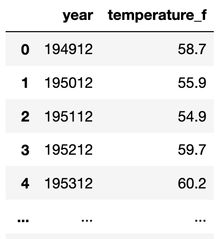

### 💻 YOUR TASK:

Below you will find some code that will extract the year from the funky yearmonth value NCEI gives us.

```
dataframe.year = pd.to_datetime(dataframe.year, format='????').dt.year
dataframe
```

> This code:
> 1. Converts the yearmonth value to a `Datetime` type (`pd.to_datetime()`)
> 2. Extracts only the year (`.dt.year`)
> 3. Saves the year value back to the dataframe "year" column.

Complete the following with the code above as a starting point:

1. Copy and paste the code above into the code cell below
2. Replace `dataframe` with the name of **your** dataframe whenever it appears.
3. Replace `????` with the correct **date formatting string**.

> HINT: Check out [the Python strftime documentation](https://docs.python.org/3/library/datetime.html#strftime-and-strptime-behavior).

### GOTCHA ALERT! We have a problem

If you run this code twice, it will not run and you will get a `ValueError`. This happens because once you have extracted the **year only**, the format string you put in no longer applies.

You don't have to do anything about this now - you can go `Run all above` (this is in the `Cell` menu in Jupyter Notebook) to reset. In the future, there are three approaches we recommend to address this sort of problem, depending on what you need your code to do:

1. Do not modify a `DataFrame` after it has been created - perform any changes you need in the **same cell** where you create the `DataFrame` using `pd.read_csv()`.
2. Create a new column when you want to compute new values (more on how to do this below).
3. Save a copy of the `DataFrame` using the `.copy()` method of `DataFrame`s and modify the copy (in the same cell).

When you reproduce this workflow in a location of your choosing, you can implement one of these strategies.

```python
# Extract the year from the date
alb_temp_df.year = pd.to_datetime(alb_temp_df.year, format='%Y%m').dt.year

alb_temp_df
```

|  | year | temperature_f |
| --- | --- | --- |
| 0 | 1938 | 85.4 |
| 1 | 1939 | 86.4 |
| 2 | 1940 | 80.0 |
| 3 | 1941 | 80.4 |
| 4 | 1942 | 79.9 |
| ... | ... | ... |
| 81 | 2019 | 82.2 |
| 82 | 2020 | 82.7 |
| 83 | 2021 | 83.4 |
| 84 | 2022 | 86.2 |
| 85 | 2023 | 79.5 |

86 rows × 2 columns

```python
# RUN THIS TEST CELL TO CHECK YOUR ANSWER - DO NOT MODIFY
year_df_resp = _
points = 0

# Check that a DataFrame was called for testing
if isinstance(year_df_resp, pd.DataFrame):
    points += 1
    print('\u2705 Great work! You called a DataFrame.')
else:
    print('\u274C Oops - make sure to call your DataFrame for testing.')

# Check that the DataFrame has the correct values
summary = [round(val, 2) for val in year_df_resp.mean().values]
if summary == [1983.5, 61.93]:
    points += 6
    print('\u2705 Great work! You correctly extracted the year.')
else:
    print('\u274C Oops - your data are not correct.')

# Subtract one point for any PEP-8 errors
tmp_path = "tmp.py"
with open(tmp_path, "w") as tmp_file:
    tmp_file.write(In[-2])

ignore_flake8 = 'W292,F401,E302,F821'
flake8_out = subprocess.run(
    ['flake8',
     '--ignore', ignore_flake8,
     '--import-order-style', 'edited',
     '--count',
     tmp_path],
    stdout=subprocess.PIPE,
).stdout.decode("ascii")
print('Formatting problems:')
print(flake8_out)
points -= int(flake8_out.splitlines()[-1])

print('You earned {} of 5 points for extracting the year'.format(points))
```

```
✅ Great work! You called a DataFrame.
❌ Oops - your data are not correct.
Formatting problems:
0

You earned 1 of 5 points for extracting the year
```

## STEP 4: CONVERT UNITS

### For scientific applications, it is often useful to have values in metric units

When you cited the data, you should have noted that temperature was in units of degrees Fahrenheit. Often we want data in metric units, because it makes important calculations (say, sensible heat from temperature) easier. Plus you don't want to be like the [NASA team who crashed a probe into Mars because different teams used different units](https://www.latimes.com/archives/la-xpm-1999-oct-01-mn-17288-story.html))!

### 💻 YOUR TASK:

The code below converts the data to Celcius, using Python mathematical **operators**, like `+`, `-`, `*`, and `/`. Again, it's not well documented and doesn't follow [PEP-8 guidelines](https://peps.python.org/pep-0008/#other-recommendations), which has caused the author to miss an **important error**!

```
dataframe['new_temperature']= dataframe['old_temperature']-32*5/9
dataframe
```

Complete the following steps:

1. Replace `dataframe` with the name of **your** `DataFrame`.
2. Replace `'old_temperature'` with the column name **you** used; Replace `'new_temperature'` with an **expressive** column name.
3. **THERE IS AN ERROR IN THE CONVERSION - Fix it!**

### Want an EXTRA CHALLENGE?

Using the code below as a framework, write and apply a **function** that converts to Celcius. You should also rewrite this function name to be more expressive.

```
def convert(temperature):
    """Convert temperature to Celcius"""
    return temperature # Put your equation in here

dataframe['temp_c'] = dataframe['temp_f'].apply(convert)
```

```python
# Define and execute function for converting incoming fahrenheit data
# to celcius
def convert(temperature_fahrenheit: float):
    """Convert temperature in Fahrenheit to Celcius"""
    return (temperature_fahrenheit - 32) * 5 / 9


alb_temp_df['temperature_c'] = alb_temp_df['temperature_f'].apply(convert)

alb_temp_df
```

|  | year | temperature_f | temperature_c |
| --- | --- | --- | --- |
| 0 | 1938 | 85.4 | 29.666667 |
| 1 | 1939 | 86.4 | 30.222222 |
| 2 | 1940 | 80.0 | 26.666667 |
| 3 | 1941 | 80.4 | 26.888889 |
| 4 | 1942 | 79.9 | 26.611111 |
| ... | ... | ... | ... |
| 81 | 2019 | 82.2 | 27.888889 |
| 82 | 2020 | 82.7 | 28.166667 |
| 83 | 2021 | 83.4 | 28.555556 |
| 84 | 2022 | 86.2 | 30.111111 |
| 85 | 2023 | 79.5 | 26.388889 |

86 rows × 3 columns

```python
# RUN THIS TEST CELL TO CHECK YOUR ANSWER - DO NOT MODIFY
celcius_df_resp = _
points = 0

# Check that a DataFrame was called for testing
if isinstance(celcius_df_resp, pd.DataFrame):
    points += 1
    print('\u2705 Great work! You called a DataFrame.')
else:
    print('\u274C Oops - make sure to call your DataFrame for testing.')

# Check that the DataFrame has the correct values
summary = [round(val, 2) for val in celcius_df_resp.mean().values]
if summary == [1983.5, 61.93, 16.63]:
    points += 9
    print('\u2705 Great work! You correctly converted units.')
else:
    print('\u274C Oops - your data are not correct.')

# Subtract one point for any PEP-8 errors
tmp_path = "tmp.py"
with open(tmp_path, "w") as tmp_file:
    tmp_file.write(In[-2])

ignore_flake8 = 'W292,F401,E302,F821'
flake8_out = subprocess.run(
    ['flake8',
     '--ignore', ignore_flake8,
     '--import-order-style', 'edited',
     '--count',
     tmp_path],
    stdout=subprocess.PIPE,
).stdout.decode("ascii")
print('Formatting problems:')
print(flake8_out)
points -= int(flake8_out.splitlines()[-1])

print('You earned {} of 10 points for converting units'.format(points))
```

```
✅ Great work! You called a DataFrame.
❌ Oops - your data are not correct.
Formatting problems:
0

You earned 1 of 10 points for converting units
```

## STEP 5: PLOT

### Plot the Maximum Annual Temperature in Los Angeles, CA, USA

Present your work visually with a time-series plot of the maximum temperature values you downloaded.

### 💻 YOUR TASK:

The code below is an attempt to plot the maximum temperature data with `Python`.

```
dataframe.hvplot(x='col_1', y='col_2')
```

It's easy to plot in Python, but not quite this easy! You'll always need to add some instructions on labels and how you want your plot to look. Using the code above as a starting point, complete the following **four** steps:

1. Change `dataframe` to **your** `DataFrame` name.
2. Change `'col_1'` and `'col_2'` to **your** column names
3. Use the `title`, `ylabel`, and `xlabel` parameters to add key text to your plot.

   > HINT: labels have to be a type in Python called a **string**. You can make a string by putting quotes around your label, just like the column names in the sample code.
4. ✎ Write a **headline** for your plot in the markdown cell below

### 🌶 If you want an EXTRA CHALLENGE:

Take a look at the [hvplot reference gallery](https://hvplot.holoviz.org/reference/index.html) to see if there's other changes you want to make to your plot. Some possibilities include:

- Remove the legend since there's only one data series
- Increase the figure size
- Increase the font size
- Change the colors
- Use a bar graph instead (usually we use lines for time series, but since this is annual it could go either way)
- [Add a trend line](https://holoviews.org/reference/elements/bokeh/Slope.html)

> HINT: to add a trend line, you will need to `import holoviews as hv` at the beginning of your notebook

```python
# Plot the Albany Temperature data over time
plot = alb_temp_df.hvplot.scatter(
    x='year', y='temperature_f',
    title='Mean Maxiumum Annual Temperature in Albany, NY, USA',
    xlabel='Year', ylabel='Temperature (°F)'
    ).opts(bgcolor='lightgray', fontsize={'title' : 16})

plot * hv.Slope.from_scatter(plot)
```

[output not shown]

[output not shown]